# Lab. 3 — Regression Analysis and Lab.

June 3rd, 2024

# Ch.9 Multicollinearity

## Multicollinearity Diagnostics

- We will use the ‘Acetylene Data’ (Example 9.1, p.299). This dataset concerns the percentage of conversion of $n$-heptance (`P`) to acetylene and three explantory variables (`Temp`, `H2`, `Cont`).
- We wish to fit a full quadratic model,
  $$P = \gamma_0 + \gamma_1 T + \gamma_2 H + \gamma_3 C + \gamma_{12} TH +
  \gamma_{13} TC + \gamma_{23} HC + \gamma_{11} T^2 + \gamma_{22} H^2 +
  \gamma_{33} C^2 + \epsilon,$$
  where $T$, $H$, $C$ are scaled variables of `Temp`, `H2`, and `Cont`, respectively.
- Use the `scale()` function to subtract average and divide by the standard deviation.

```r
acetylene <- read.csv("acetylene.csv")
colnames(acetylene) <- c("Obs", "P", "Temp", "H2", "Cont")
lmfit <- lm(P ~ poly(scale(Temp), scale(H2), scale(Cont), degree = 2, raw = TRUE),
            data = acetylene)
summary(lmfit)
```

#### LS fit

- The least-squares fit is
  $$\hat{P} =
  35.896 +
  4.004 T +
  2.778 H
  -8.042 C
  -6.457 TH
  -26.98 TC
  -3.768 HC
  -12.524 T^2
  -0.973 H^2
  -11.593 C^2.$$

#### R output

```
##
## Call:
## lm(formula = P ~ poly(scale(Temp), scale(H2), scale(Cont), degree = 2,
##     raw = TRUE), data = acetylene)
##
## Residuals:
##     Min      1Q  Median      3Q     Max
## -1.3499 -0.3411  0.1297  0.5011  0.6720
##
## Coefficients:
##                                                                        Estimate
## (Intercept)                                                             35.8958
## poly(scale(Temp), scale(H2), scale(Cont), degree = 2, raw = TRUE)1.0.0   4.0038
## poly(scale(Temp), scale(H2), scale(Cont), degree = 2, raw = TRUE)2.0.0 -12.5236
## poly(scale(Temp), scale(H2), scale(Cont), degree = 2, raw = TRUE)0.1.0   2.7783
## poly(scale(Temp), scale(H2), scale(Cont), degree = 2, raw = TRUE)1.1.0  -6.4568
## poly(scale(Temp), scale(H2), scale(Cont), degree = 2, raw = TRUE)0.2.0  -0.9727
## poly(scale(Temp), scale(H2), scale(Cont), degree = 2, raw = TRUE)0.0.1  -8.0423
## poly(scale(Temp), scale(H2), scale(Cont), degree = 2, raw = TRUE)1.0.1 -26.9804
## poly(scale(Temp), scale(H2), scale(Cont), degree = 2, raw = TRUE)0.1.1  -3.7681
## poly(scale(Temp), scale(H2), scale(Cont), degree = 2, raw = TRUE)0.0.2 -11.5932
##                                                                        Std. Error
## (Intercept)                                                                1.0916
## poly(scale(Temp), scale(H2), scale(Cont), degree = 2, raw = TRUE)1.0.0     4.5087
## poly(scale(Temp), scale(H2), scale(Cont), degree = 2, raw = TRUE)2.0.0    12.3238
## poly(scale(Temp), scale(H2), scale(Cont), degree = 2, raw = TRUE)0.1.0     0.3071
## poly(scale(Temp), scale(H2), scale(Cont), degree = 2, raw = TRUE)1.1.0     1.4660
## poly(scale(Temp), scale(H2), scale(Cont), degree = 2, raw = TRUE)0.2.0     0.3746
## poly(scale(Temp), scale(H2), scale(Cont), degree = 2, raw = TRUE)0.0.1     6.0707
## poly(scale(Temp), scale(H2), scale(Cont), degree = 2, raw = TRUE)1.0.1    21.0213
## poly(scale(Temp), scale(H2), scale(Cont), degree = 2, raw = TRUE)0.1.1     1.6553
## poly(scale(Temp), scale(H2), scale(Cont), degree = 2, raw = TRUE)0.0.2     7.7063
##                                                                        t value
## (Intercept)                                                             32.884
## poly(scale(Temp), scale(H2), scale(Cont), degree = 2, raw = TRUE)1.0.0   0.888
## poly(scale(Temp), scale(H2), scale(Cont), degree = 2, raw = TRUE)2.0.0  -1.016
## poly(scale(Temp), scale(H2), scale(Cont), degree = 2, raw = TRUE)0.1.0   9.048
## poly(scale(Temp), scale(H2), scale(Cont), degree = 2, raw = TRUE)1.1.0  -4.404
## poly(scale(Temp), scale(H2), scale(Cont), degree = 2, raw = TRUE)0.2.0  -2.597
## poly(scale(Temp), scale(H2), scale(Cont), degree = 2, raw = TRUE)0.0.1  -1.325
```

[output cut: 16 more lines]

```
## poly(scale(Temp), scale(H2), scale(Cont), degree = 2, raw = TRUE)1.0.0
## poly(scale(Temp), scale(H2), scale(Cont), degree = 2, raw = TRUE)2.0.0
## poly(scale(Temp), scale(H2), scale(Cont), degree = 2, raw = TRUE)0.1.0 ***
## poly(scale(Temp), scale(H2), scale(Cont), degree = 2, raw = TRUE)1.1.0 **
## poly(scale(Temp), scale(H2), scale(Cont), degree = 2, raw = TRUE)0.2.0 *
## poly(scale(Temp), scale(H2), scale(Cont), degree = 2, raw = TRUE)0.0.1
## poly(scale(Temp), scale(H2), scale(Cont), degree = 2, raw = TRUE)1.0.1
## poly(scale(Temp), scale(H2), scale(Cont), degree = 2, raw = TRUE)0.1.1 .
## poly(scale(Temp), scale(H2), scale(Cont), degree = 2, raw = TRUE)0.0.2
## ---
## Signif. codes:  0 '***' 0.001 '**' 0.01 '*' 0.05 '.' 0.1 ' ' 1
##
## Residual standard error: 0.9014 on 6 degrees of freedom
## Multiple R-squared:  0.9977, Adjusted R-squared:  0.9943
## F-statistic: 289.7 on 9 and 6 DF,  p-value: 3.225e-07
```

- Fix `H2` to 12.44 (average of `H2`) and draw the regression surface. Mark the observed values by black points. It can be seen from the figure below, that the model fits the data well, but extrapolation performance is poor. For example, some predicted values of `P` are negative (it should be in [0,100], since this value represents a percentage). A likely cause of this is the strong correlation between `Cont` and `Temp`, which makes the least-squares estimates of the regression coefficients very poor.

[interactive chart not shown]

### Examination of the Correlation Matrix

- If regressors $x_i$ and $x_j$ are nearly linearly dependent, then $|r_{ij}|$ ($r_{ij}$: correlation between $x_i$ and $x_j$) will be near 1.
- Suppose that $x_i$s are scaled as
  $$x_i^* = \frac{x_i - \bar{x}_i}{s_{x_i}} \frac{1}{\sqrt{n-1}},$$
  where $s_{x_i}$ is the standard deviation of $x_i$. With $\mathbf{X} = [x_1^*, \dots, x_k^*]$, $\mathbf{X}^\top\mathbf{X} = (r_{ij})_{ij}$.
- However, this is helpful in detecting near-linear dependence between **pairs of regressors** only.

```r
X <- model.matrix(lmfit)
XPX <- cor(X[,-1])
XPX
# X2 <- scale(X[,-1])/sqrt(15)
# t(X2) %*% X2 ## equivalent to `cor(X[,-1])`.
```

#### `XPX`

|  | T | TT | H | TH | HH | C | TC | HC | CC |
| --- | --- | --- | --- | --- | --- | --- | --- | --- | --- |
| T | 1.000 | -0.271 | 0.224 | -0.132 | 0.031 | -0.958 | 0.443 | 0.206 | -0.577 |
| TT | -0.271 | 1.000 | -0.148 | 0.246 | -0.124 | 0.501 | -0.972 | -0.279 | 0.894 |
| H | 0.224 | -0.148 | 1.000 | 0.039 | 0.498 | -0.240 | 0.192 | -0.023 | -0.224 |
| TH | -0.132 | 0.246 | 0.039 | 1.000 | 0.398 | 0.195 | -0.265 | -0.974 | 0.275 |
| HH | 0.031 | -0.124 | 0.498 | 0.398 | 1.000 | -0.018 | 0.126 | -0.375 | -0.158 |
| C | -0.958 | 0.501 | -0.240 | 0.195 | -0.018 | 1.000 | -0.661 | -0.274 | 0.765 |
| TC | 0.443 | -0.972 | 0.192 | -0.265 | 0.126 | -0.661 | 1.000 | 0.324 | -0.972 |
| HC | 0.206 | -0.279 | -0.023 | -0.974 | -0.375 | -0.274 | 0.324 | 1.000 | -0.359 |
| CC | -0.577 | 0.894 | -0.224 | 0.275 | -0.158 | 0.765 | -0.972 | -0.359 | 1.000 |

#### R output

```
##                                                                        poly(scale(Temp), scale(H2), scale(Cont), degree = 2, raw = TRUE)1.0.0
## poly(scale(Temp), scale(H2), scale(Cont), degree = 2, raw = TRUE)1.0.0                                                              1.0000000
## poly(scale(Temp), scale(H2), scale(Cont), degree = 2, raw = TRUE)2.0.0                                                             -0.2707456
## poly(scale(Temp), scale(H2), scale(Cont), degree = 2, raw = TRUE)0.1.0                                                              0.2236278
## poly(scale(Temp), scale(H2), scale(Cont), degree = 2, raw = TRUE)1.1.0                                                             -0.1324174
## poly(scale(Temp), scale(H2), scale(Cont), degree = 2, raw = TRUE)0.2.0                                                              0.0309599
## poly(scale(Temp), scale(H2), scale(Cont), degree = 2, raw = TRUE)0.0.1                                                             -0.9582041
## poly(scale(Temp), scale(H2), scale(Cont), degree = 2, raw = TRUE)1.0.1                                                              0.4428236
## poly(scale(Temp), scale(H2), scale(Cont), degree = 2, raw = TRUE)0.1.1                                                              0.2055387
## poly(scale(Temp), scale(H2), scale(Cont), degree = 2, raw = TRUE)0.0.2                                                             -0.5767868
##                                                                        poly(scale(Temp), scale(H2), scale(Cont), degree = 2, raw = TRUE)2.0.0
## poly(scale(Temp), scale(H2), scale(Cont), degree = 2, raw = TRUE)1.0.0                                                             -0.2707456
## poly(scale(Temp), scale(H2), scale(Cont), degree = 2, raw = TRUE)2.0.0                                                              1.0000000
## poly(scale(Temp), scale(H2), scale(Cont), degree = 2, raw = TRUE)0.1.0                                                             -0.1477108
## poly(scale(Temp), scale(H2), scale(Cont), degree = 2, raw = TRUE)1.1.0                                                              0.2463122
## poly(scale(Temp), scale(H2), scale(Cont), degree = 2, raw = TRUE)0.2.0                                                             -0.1235907
## poly(scale(Temp), scale(H2), scale(Cont), degree = 2, raw = TRUE)0.0.1                                                              0.5009622
## poly(scale(Temp), scale(H2), scale(Cont), degree = 2, raw = TRUE)1.0.1                                                             -0.9722442
## poly(scale(Temp), scale(H2), scale(Cont), degree = 2, raw = TRUE)0.1.1                                                             -0.2792725
## poly(scale(Temp), scale(H2), scale(Cont), degree = 2, raw = TRUE)0.0.2                                                              0.8936644
##                                                                        poly(scale(Temp), scale(H2), scale(Cont), degree = 2, raw = TRUE)0.1.0
## poly(scale(Temp), scale(H2), scale(Cont), degree = 2, raw = TRUE)1.0.0                                                             0.22362776
## poly(scale(Temp), scale(H2), scale(Cont), degree = 2, raw = TRUE)2.0.0                                                            -0.14771083
## poly(scale(Temp), scale(H2), scale(Cont), degree = 2, raw = TRUE)0.1.0                                                             1.00000000
## poly(scale(Temp), scale(H2), scale(Cont), degree = 2, raw = TRUE)1.1.0                                                             0.03868762
## poly(scale(Temp), scale(H2), scale(Cont), degree = 2, raw = TRUE)0.2.0                                                             0.49754636
## poly(scale(Temp), scale(H2), scale(Cont), degree = 2, raw = TRUE)0.0.1                                                            -0.24023098
## poly(scale(Temp), scale(H2), scale(Cont), degree = 2, raw = TRUE)1.0.1                                                             0.19226267
## poly(scale(Temp), scale(H2), scale(Cont), degree = 2, raw = TRUE)0.1.1                                                            -0.02306559
## poly(scale(Temp), scale(H2), scale(Cont), degree = 2, raw = TRUE)0.0.2                                                            -0.22390584
##                                                                        poly(scale(Temp), scale(H2), scale(Cont), degree = 2, raw = TRUE)1.1.0
## poly(scale(Temp), scale(H2), scale(Cont), degree = 2, raw = TRUE)1.0.0                                                            -0.13241739
## poly(scale(Temp), scale(H2), scale(Cont), degree = 2, raw = TRUE)2.0.0                                                             0.24631222
## poly(scale(Temp), scale(H2), scale(Cont), degree = 2, raw = TRUE)0.1.0                                                             0.03868762
## poly(scale(Temp), scale(H2), scale(Cont), degree = 2, raw = TRUE)1.1.0                                                             1.00000000
## poly(scale(Temp), scale(H2), scale(Cont), degree = 2, raw = TRUE)0.2.0                                                             0.39789760
## poly(scale(Temp), scale(H2), scale(Cont), degree = 2, raw = TRUE)0.0.1                                                             0.19498531
## poly(scale(Temp), scale(H2), scale(Cont), degree = 2, raw = TRUE)1.0.1                                                            -0.26485039
## poly(scale(Temp), scale(H2), scale(Cont), degree = 2, raw = TRUE)0.1.1                                                            -0.97448134
## poly(scale(Temp), scale(H2), scale(Cont), degree = 2, raw = TRUE)0.0.2                                                             0.27476802
```

[output cut: 35 more lines]

```
## poly(scale(Temp), scale(H2), scale(Cont), degree = 2, raw = TRUE)0.2.0                                                            -0.37460454
## poly(scale(Temp), scale(H2), scale(Cont), degree = 2, raw = TRUE)0.0.1                                                            -0.27411884
## poly(scale(Temp), scale(H2), scale(Cont), degree = 2, raw = TRUE)1.0.1                                                             0.32351596
## poly(scale(Temp), scale(H2), scale(Cont), degree = 2, raw = TRUE)0.1.1                                                             1.00000000
## poly(scale(Temp), scale(H2), scale(Cont), degree = 2, raw = TRUE)0.0.2                                                            -0.35852931
##                                                                        poly(scale(Temp), scale(H2), scale(Cont), degree = 2, raw = TRUE)0.0.2
## poly(scale(Temp), scale(H2), scale(Cont), degree = 2, raw = TRUE)1.0.0                                                             -0.5767868
## poly(scale(Temp), scale(H2), scale(Cont), degree = 2, raw = TRUE)2.0.0                                                              0.8936644
## poly(scale(Temp), scale(H2), scale(Cont), degree = 2, raw = TRUE)0.1.0                                                             -0.2239058
## poly(scale(Temp), scale(H2), scale(Cont), degree = 2, raw = TRUE)1.1.0                                                              0.2747680
## poly(scale(Temp), scale(H2), scale(Cont), degree = 2, raw = TRUE)0.2.0                                                             -0.1579789
## poly(scale(Temp), scale(H2), scale(Cont), degree = 2, raw = TRUE)0.0.1                                                              0.7651532
## poly(scale(Temp), scale(H2), scale(Cont), degree = 2, raw = TRUE)1.0.1                                                             -0.9721670
## poly(scale(Temp), scale(H2), scale(Cont), degree = 2, raw = TRUE)0.1.1                                                             -0.3585293
## poly(scale(Temp), scale(H2), scale(Cont), degree = 2, raw = TRUE)0.0.2                                                              1.0000000
```

### Variance Inflation Factors (VIFs)

- To compute VIF, use the `vif()` function from the R package **rms**.
- The textbook suggests using `vif()` from the package **car**. However, this function does not work properly for `lm` objects obtained from the `poly()` function.
- The maximum VIF of the Acetylene dataset is 6563.35, which means that multicollinearity problem exists. Also, linear terms involving `T` and `C` have large VIFs, indicating they are involved in the multicollinearity.

```r
# install.packages("rms")
library(rms)
vif(lmfit)
```

#### VIFs

| Regressor | VIF |
| --- | --- |
| T | 375.247759 |
| TT | 1762.575365 |
| H | 1.740631 |
| TH | 31.037059 |
| HH | 3.164318 |
| C | 680.280039 |
| TC | 6563.345193 |
| HC | 35.611286 |
| CC | 1156.766284 |

#### R output

```
## poly(scale(Temp), scale(H2), scale(Cont), degree = 2, raw = TRUE)1.0.0
##                                                             375.247759
## poly(scale(Temp), scale(H2), scale(Cont), degree = 2, raw = TRUE)2.0.0
##                                                            1762.575365
## poly(scale(Temp), scale(H2), scale(Cont), degree = 2, raw = TRUE)0.1.0
##                                                               1.740631
## poly(scale(Temp), scale(H2), scale(Cont), degree = 2, raw = TRUE)1.1.0
##                                                              31.037059
## poly(scale(Temp), scale(H2), scale(Cont), degree = 2, raw = TRUE)0.2.0
##                                                               3.164318
## poly(scale(Temp), scale(H2), scale(Cont), degree = 2, raw = TRUE)0.0.1
##                                                             680.280039
## poly(scale(Temp), scale(H2), scale(Cont), degree = 2, raw = TRUE)1.0.1
##                                                            6563.345193
## poly(scale(Temp), scale(H2), scale(Cont), degree = 2, raw = TRUE)0.1.1
##                                                              35.611286
## poly(scale(Temp), scale(H2), scale(Cont), degree = 2, raw = TRUE)0.0.2
##                                                            1156.766284
```

- Using the relationship that $\operatorname{VIF}_j = C_{jj}$, where $\mathbf{C} = (C_{ij})_{ij}$ is the inverse of the correlation matrix, the following code derives the equivalent result. Refer to lecture note Ch.9, p.2.

```r
XPX |> solve() |> diag()
```

### Eigensystem Analysis

- Inspect the condition number of the correlation matrix of regressors. The function `kappa()` computes the condition number of a matrix. When `exact = FALSE`, it approximates the computation.
- Following result indicates a problem with multicollinearity for the Acetylene dataset.

```r
kappa(XPX, exact = TRUE)
```

```
## [1] 43381.31
```

- Condition number is defined as $\kappa = \lambda_\text{max}/\lambda_\text{min}$, where $\lambda$ denotes the eigenvalue of the correlation matrix.

```r
e <- eigen(XPX)$values # eigenvalues
max(e) / min(e)
```

```
## [1] 43381.31
```

## Ridge Regression

- Ridge regression can be used when there is a problem with the multicollinearity. The ridge estimator $\hat{\boldsymbol{\beta}}_R$ is defined as the minimizer of
  $$(\mathbf{y} - \mathbf{X}\boldsymbol{\beta})^\top(\mathbf{y} -
  \mathbf{X}\boldsymbol{\beta}) + k
  \boldsymbol{\beta}^\top\boldsymbol{\beta},$$
  where $k\geq 0$ is a constant. It can be shown that the solution to the problem above is
  $$\hat{\boldsymbol{\beta}}_R = (\mathbf{X}^\top\mathbf{X} +
  k\mathbf{I})^{-1}\mathbf{X}^\top\boldsymbol{y}.$$
- The R package **glmnet** provides a function for fitting the ridge regression model. (And much more models that are not the topic of this course.)

> CAUTION 1: In `glmnet()`, `alpha` should be set to `0` to conduct the ridge regression.

> CAUTION 2: The `lambda` argument is a little bit different from the $k$ used above. It is a regularization argument as $k$, but due to different objective function used in the `glmnet()`, $k$ and `lambda`’s scales are different.

```r
# install.packages("glmnet")
library(glmnet)
X <- model.matrix(lmfit)[,-1]
y <- acetylene$P
lmfit.ridge <- glmnet(x = X, y = y, alpha = 0) # `lambda`s are automatically chosen
lmfit.ridge |> coef()
```

```
##   [[ suppressing 100 column names 's0', 's1', 's2' ... ]]
```

|  | 2.76 | 2.52 | 2.29 | 2.09 | 1.9 | 1.73 | 1.58 | 1.44 | 1.31 | 1.19 | 1.09 |
| --- | --- | --- | --- | --- | --- | --- | --- | --- | --- | --- | --- |
| (Intercept) | 35.7382442 | 35.6693489 | 35.6053720 | 35.5449190 | 35.4882523 | 35.4354216 | 35.3869999 | 35.3413265 | 35.2991919 | 35.2606904 | 35.2250779 |
| T | 5.2719868 | 5.3471783 | 5.4225148 | 5.4931387 | 5.5603450 | 5.6246250 | 5.6878679 | 5.7461145 | 5.8019818 | 5.8561320 | 5.9074487 |
| TT | 1.6645082 | 1.7005884 | 1.7324682 | 1.7600509 | 1.7846138 | 1.8058822 | 1.8254300 | 1.8379648 | 1.8503022 | 1.8601798 | 1.8657934 |
| H | 2.1734875 | 2.2041801 | 2.2332287 | 2.2603584 | 2.2856608 | 2.3092349 | 2.3311752 | 2.3515703 | 2.3703584 | 2.3877497 | 2.4038404 |
| TH | -1.7124183 | -1.7546402 | -1.7974048 | -1.8423723 | -1.8888686 | -1.9370727 | -1.9849720 | -2.0390365 | -2.0933538 | -2.1494605 | -2.2108020 |
| HH | -0.4426251 | -0.4492603 | -0.4558190 | -0.4616837 | -0.4670609 | -0.4719967 | -0.4767583 | -0.4807233 | -0.4843832 | -0.4877834 | -0.4907280 |
| C | -4.1941753 | -4.2394135 | -4.2765857 | -4.3122716 | -4.3446731 | -4.3736337 | -4.3962819 | -4.4207185 | -4.4410068 | -4.4575373 | -4.4732418 |
| TC | -0.4263197 | -0.4567897 | -0.4882166 | -0.5179218 | -0.5459787 | -0.5728431 | -0.5988929 | -0.6245516 | -0.6477414 | -0.6702904 | -0.6922528 |
| HC | 1.3843902 | 1.3675967 | 1.3478206 | 1.3242735 | 1.2974389 | 1.2671869 | 1.2352357 | 1.1962090 | 1.1552632 | 1.1110130 | 1.0604223 |
| CC | -0.5223271 | -0.5020726 | -0.4844526 | -0.4657518 | -0.4474259 | -0.4296351 | -0.4146965 | -0.3964193 | -0.3800635 | -0.3651624 | -0.3493249 |

```r
lmfit.ridge$lambda # 100 lambda values are automatically chosen
```

```
##   [1] 10887.713658  9920.479184  9039.171155  8236.156103  7504.478695
##   [6]  6837.801491  6230.350052  5676.862925  5172.546069  4713.031332
##  [11]  4294.338618  3912.841411  3565.235364  3248.509681  2959.921034
##  [16]  2696.969807  2457.378443  2239.071715  2040.158755  1858.916674
##  [21]  1693.775640  1543.305280  1406.202293  1281.279157  1167.453848
##  [26]  1063.740466   969.240694   883.136022   804.680652   733.195041
##  [31]   668.060014   608.711404   554.635160   505.362901   460.467854
##  [36]   419.561159   382.288502   348.327045   317.382630   289.187232
##  [41]   263.496636   240.088321   218.759536   199.325542   181.618010
##  [46]   165.483567   150.782463   137.387364   125.182249   114.061403
##  [51]   103.928503    94.695781    86.283269    78.618101    71.633886
##  [56]    65.270129    59.471710    54.188407    49.374459    44.988168
##  [61]    40.991543    37.349967    34.031899    31.008599    28.253881
##  [66]    25.743884    23.456868    21.373024    19.474304    17.744260
##  [71]    16.167909    14.731597    13.422882    12.230430    11.143913
##  [76]    10.153918     9.251872     8.429961     7.681067     6.998702
##  [81]     6.376957     5.810445     5.294261     4.823934     4.395389
##  [86]     4.004915     3.649129     3.324950     3.029571     2.760432
##  [91]     2.515203     2.291759     2.088166     1.902659     1.733632
##  [96]     1.579621     1.439292     1.311429     1.194925     1.088771
```

- Draw the **ridge trace**. We can see that $\hat{\boldsymbol{\beta}}^\top \hat{\boldsymbol{\beta}}$ decreases as `lambda` gets large.

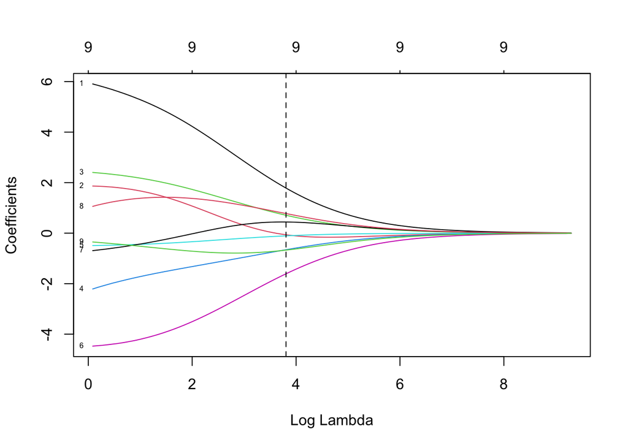

```r
# ridge trace
# ?plot.glmnet
plot(lmfit.ridge, xvar = "lambda", label = TRUE)
abline(v = log(lmfit.ridge$lambda[60]), lty = 2)
```

- For example when `lambda` = 44.988, the resulting model fit is

```r
lmfit.ridge$lambda[60]
coef(lmfit.ridge)[, 60]
```

[output not shown]

- Use the `predict()` function to predict fitted values or coefficients. The `s` argument denotes `lambda`. The `newx` argument is similar to the `newdata` argument used in the previous lab sessions.

```r
# ?predict.glm
# `s` does *not* have to be included in lmfit.ridge$lambda !
predict(lmfit.ridge, s = 45, type ="coefficients") # estimation of beta's when lambda = 45
```

```
## 10 x 1 sparse Matrix of class "dgCMatrix"
##                                                                                 s1
## (Intercept)                                                            37.60559179
## poly(scale(Temp), scale(H2), scale(Cont), degree = 2, raw = TRUE)1.0.0  1.78376453
## poly(scale(Temp), scale(H2), scale(Cont), degree = 2, raw = TRUE)2.0.0 -0.06465125
## poly(scale(Temp), scale(H2), scale(Cont), degree = 2, raw = TRUE)0.1.0  0.70845271
## poly(scale(Temp), scale(H2), scale(Cont), degree = 2, raw = TRUE)1.1.0 -0.65589130
## poly(scale(Temp), scale(H2), scale(Cont), degree = 2, raw = TRUE)0.2.0 -0.10679761
## poly(scale(Temp), scale(H2), scale(Cont), degree = 2, raw = TRUE)0.0.1 -1.60848373
## poly(scale(Temp), scale(H2), scale(Cont), degree = 2, raw = TRUE)1.0.1  0.44222276
## poly(scale(Temp), scale(H2), scale(Cont), degree = 2, raw = TRUE)0.1.1  0.77551546
## poly(scale(Temp), scale(H2), scale(Cont), degree = 2, raw = TRUE)0.0.2 -0.67113107
```

```r
predict(lmfit.ridge, s = 45, newx = X) # predictions at observed points with the model fitted at lambda = 45
```

```
##          s1
## 1  40.46531
## 2  40.32247
## 3  40.11051
## 4  39.81021
## 5  39.33901
## 6  38.26642
## 7  36.16148
## 8  36.70717
## 9  37.56020
## 10 38.03076
## 11 38.09362
## 12 38.46134
## 13 27.06821
## 14 25.96777
## 15 28.81956
## 16 32.51595
```

- Fix `H2` to 12.44 (average of `H2`) and draw the regression surface. Mark the observed values by black points. It can be seen from the figure below, that the model fits the data well, and the **extrapolation performance is much more enhanced**. That is, the ridge model gives much more realistic predictions when extrapolating than does the ordinary least squares.

[interactive chart not shown]

# Ch.10 Variable Selection and Model Building

- In most practical problems, the analyst has a large pool of possible candidate regressors, of which only a few are likely to be important. Finding an appropriate subset of regressors for the model is called the **variable selection problem**.

## Criteria for Evaluating Subset Regression Models

- We will use the ‘Hald Cement Data’ (Table B.21, p.593). This dataset contains 13 observations with five variables (`y`, `x1`, `x2`, `x3`, `x4`).

```r
hald <- read.csv("hald.csv")
lmfit <- lm(y ~ ., data = hald) # y ~ x1 + x2 + x3 + x4
```

- Suppose that the model includes $p$ terms, i.e., $p-1$ regressors and an intercept.

| Criterion | Formula | R function |
| --- | --- | --- |
| Coefficient of multiple determination ($R_p^2$) | $R_p^2 = \frac{SS_R(p)}{SS_T}$ | `summary(lmfit)$r.squared` |
| Adjusted $R^2$ ($R^2_{Adj,p}$) | $R_{Adj,p}^2 = 1 - \frac{n-1}{n-p}(1-R^2_p)$ | `summary(lmfit)$adj.r.squared` |
| Residual mean square ($MS_E(p)$) | $MS_E(p) = \frac{SS_E(p)}{n-p}$ | `summary(lmfit)$sigma^2` |
| Mallow’s $C_p$ | $C_p = \frac{SS_E(p)}{\hat\sigma^2} - n + 2p$ | - |
| Akaike Information Criterion (AIC) | $AIC = -2\log(L) + 2p$ | `AIC(lmfit)` |
| Bayesian Information Criterion (BIC) | $BIC = -2\log(L) + p\log(n)$ | `BIC(lmfit)` |

> CAUTION: Output of `AIC()` and `BIC()` **differs** from the formula given above by an additive constant independent of $p$.

```r
summary(lmfit)$r.squared # R^2
```

```
## [1] 0.9823756
```

```r
summary(lmfit)$adj.r.squared # R^2_Adj
```

```
## [1] 0.9735634
```

```r
summary(lmfit)$sigma^2 # MSE
```

```
## [1] 5.982955
```

```r
AIC(lmfit) # AIC
```

```
## [1] 65.83669
```

```r
BIC(lmfit) # BIC
```

```
## [1] 69.22639
```

## Variable Selection

### All possible regressions

- Use the `regsubsets()` function in the **leaps** package. Set the argument `method` to `"exhaustive"` to conduct ‘all possible regressions’.
- Note that when $p$ is fixed, all criteria above are equivalent. That is, whether you use AIC, BIC, SSE, $R^2$… does not affect the choice of the ‘best subset of regressors’ when $p$ is fixed.

```r
# install.packages("leaps")
library(leaps)
reg <- regsubsets(y ~ ., data = hald, method = "exhaustive")
reg.summary <- summary(reg)
data.frame(reg.summary$outmat,
           R2 = reg.summary$rsq,
           R2Adj = reg.summary$adjr2,
           SSE = reg.summary$rss,
           Cp = reg.summary$cp,
           BIC = reg.summary$bic)
```

```
##          x1 x2 x3 x4        R2     R2Adj       SSE         Cp        BIC
## 1  ( 1 )           * 0.6745420 0.6449549 883.86692 138.730833  -9.462884
## 2  ( 1 )  *  *       0.9786784 0.9744140  57.90448   2.678242 -42.329587
## 3  ( 1 )  *  *     * 0.9823355 0.9764473  47.97273   3.018233 -42.210745
## 4  ( 1 )  *  *  *  * 0.9823756 0.9735634  47.86364   5.000000 -39.675391
```

- Among the $2^4$ possible regression equations, the output above shows the best subset for each $k=1, 2, 3, 4$.
- When using $R^2_{Adj}$ for criterion, the regression model with `x1`, `x2`, and `x4` is the ‘best’. (Intercept term is always included.)

```r
coef(reg, 3) # estimated regression coefficients when k=3
```

```
## (Intercept)          x1          x2          x4
##  71.6483070   1.4519380   0.4161098  -0.2365402
```

- When using $R^2$ for criterion, we see that after the two regressors (`x1` and `x2`) are in the model, there is little to be gained in terms of $R^2$ by introducing additional variables.

```r
# ?plot.regsubsets
# Plots a table of models showing which variables are in each model. The models are ordered by the specified model selection statistic (`scale` argument).
plot(reg, scale="bic")
plot(reg, scale="Cp")
plot(reg, scale="adjr2")
plot(reg, scale="r2")
```

#### `bic`

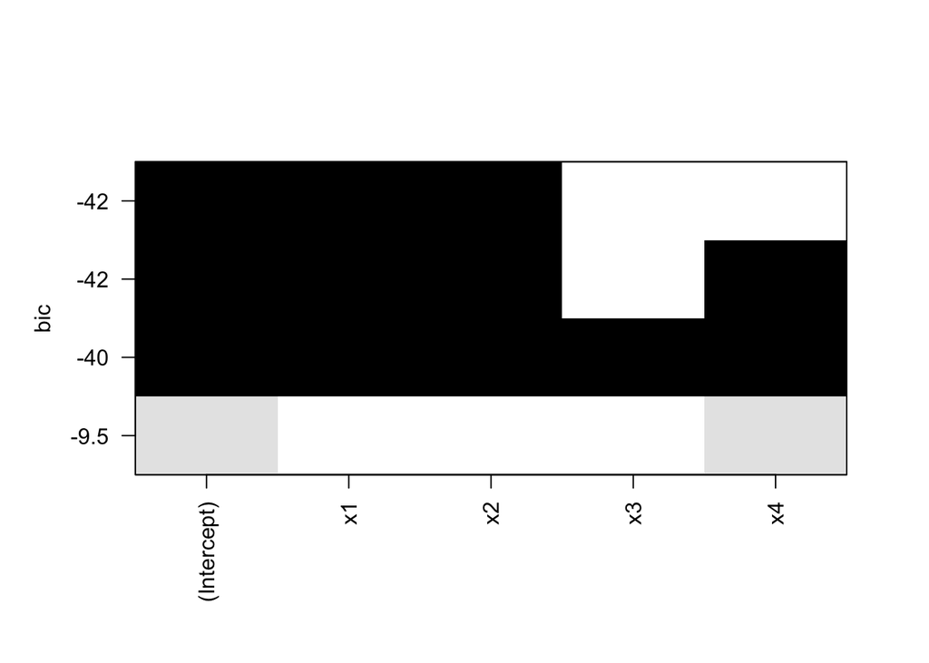

#### `Cp`

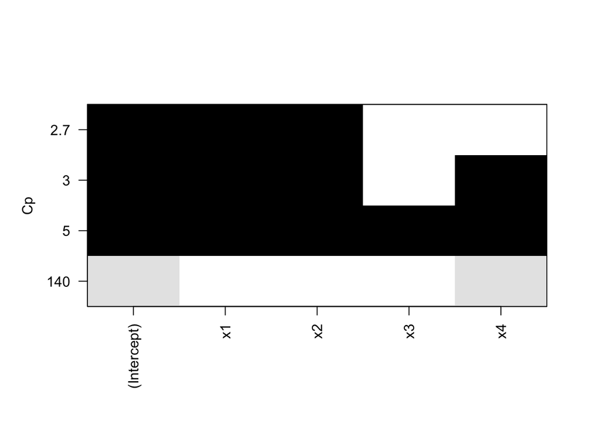

#### `adjr2`

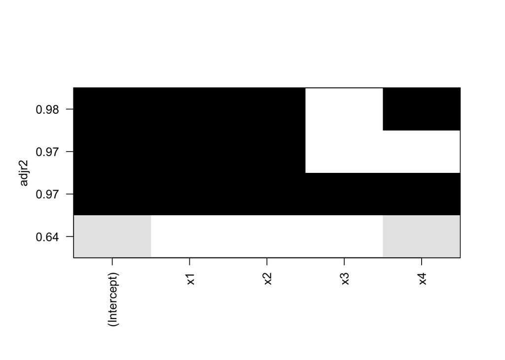

#### `r2`

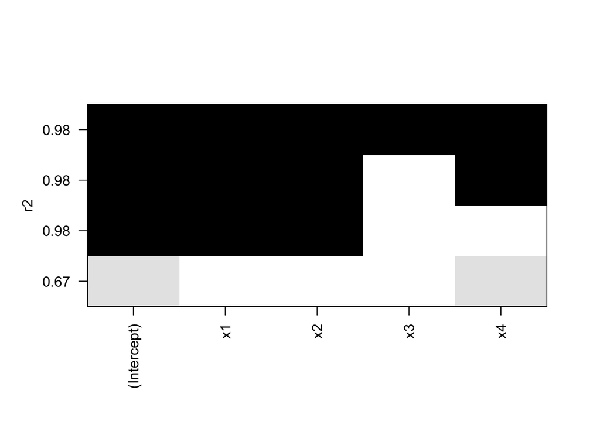

### Stepwise regression models

- Evaluating all possible regressions can be computationally burdensome. Hence, when there are many regressor candidates, one may prefer stepwise-type procedures: (1) forward selection, (2) backward elimination, and (3) stepwise regression. We only consider (1) and (2) in this lab session.
- Forward selection:

```r
reg <- regsubsets(y ~ ., data = hald, method = "forward")
reg.summary <- summary(reg)
data.frame(reg.summary$outmat,
           R2 = reg.summary$rsq,
           R2Adj = reg.summary$adjr2,
           SSE = reg.summary$rss,
           Cp = reg.summary$cp,
           BIC = reg.summary$bic)
```

```
##          x1 x2 x3 x4        R2     R2Adj       SSE         Cp        BIC
## 1  ( 1 )           * 0.6745420 0.6449549 883.86692 138.730833  -9.462884
## 2  ( 1 )  *        * 0.9724710 0.9669653  74.76211   5.495851 -39.007873
## 3  ( 1 )  *  *     * 0.9823355 0.9764473  47.97273   3.018233 -42.210745
## 4  ( 1 )  *  *  *  * 0.9823756 0.9735634  47.86364   5.000000 -39.675391
```

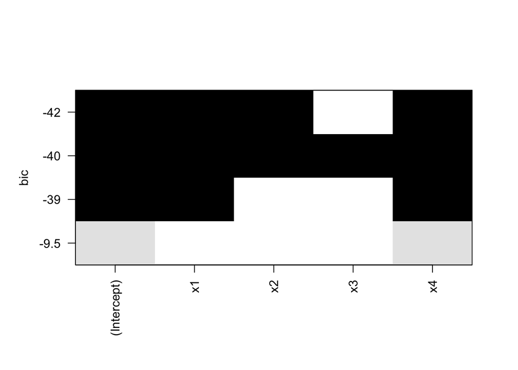

```r
plot(reg) # different from the all possible regressions
```

- Backward elimination:

```r
reg <- regsubsets(y ~ ., data = hald, method = "backward")
reg.summary <- summary(reg)
data.frame(reg.summary$outmat,
           R2 = reg.summary$rsq,
           R2Adj = reg.summary$adjr2,
           SSE = reg.summary$rss,
           Cp = reg.summary$cp,
           BIC = reg.summary$bic)
```

```
##          x1 x2 x3 x4        R2     R2Adj       SSE         Cp        BIC
## 1  ( 1 )     *       0.6662683 0.6359290 906.33634 142.486407  -9.136532
## 2  ( 1 )  *  *       0.9786784 0.9744140  57.90448   2.678242 -42.329587
## 3  ( 1 )  *  *     * 0.9823355 0.9764473  47.97273   3.018233 -42.210745
## 4  ( 1 )  *  *  *  * 0.9823756 0.9735634  47.86364   5.000000 -39.675391
```

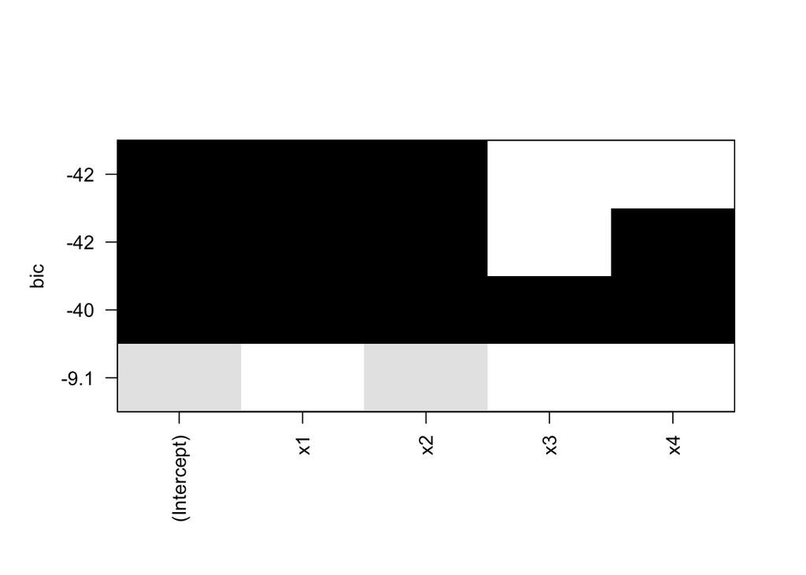

```r
plot(reg)
```

- `step()` function conducts a stepwise model selection by AIC. There is no need to install any package when using this function. We do not cover this function in this lab session.

# Ch.12 Introduction to Nonlinear Regression

- We consider the ‘Puromycin Data’ (Example 12.4, p.414). The Michaelis–Menten model is used to relate the initial velocity of an enzymatic reaction $y$ to the substrate concentration $x$. The model is
  $$y = \frac{\theta_1 x}{x + \theta_2} + \epsilon.$$

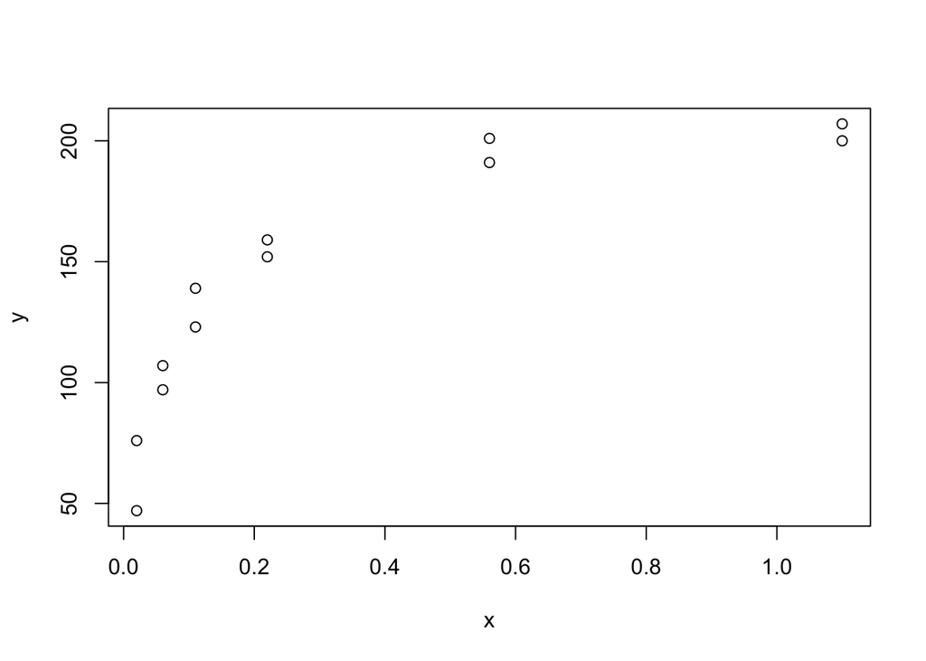

```r
library(readxl)
Puromycin = read_xls("Puromycin.xls")
plot(y ~ x, data = Puromycin)
```

- The model above can be linearlized as
  $$y^\prime = \beta_0 + \beta_1 u + \epsilon$$
  where $y^\prime = 1/y$, $u = 1/x$, $\beta_0 = 1/\theta_1$, and $\beta_1 = \theta_2/\theta_1$ (see the lecture note).
- Observe that the constant-variance assumption is unreasonable for the transformed model. Also, model does not fit the data well at high values of $x$. This explains the need for a **nonlinear regression**.

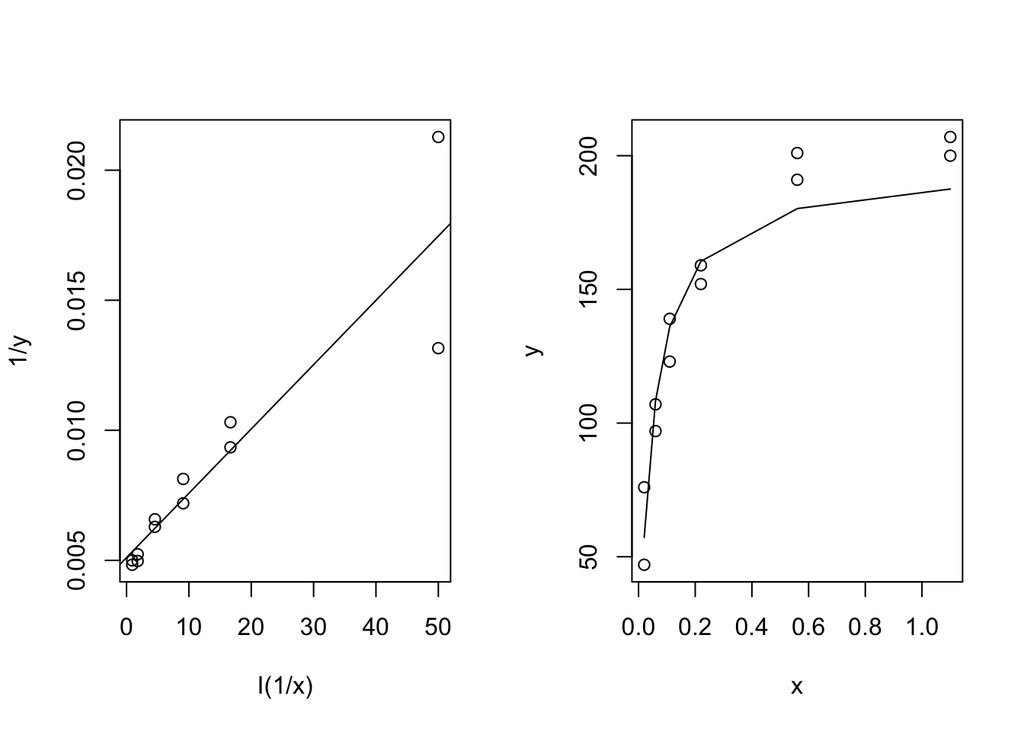

```r
lmfit <- lm(1/y ~ I(1/x), data = Puromycin)
par(mfrow = c(1,2))
plot(1/y ~ I(1/x), data = Puromycin)
abline(lmfit)
plot(y ~ x, data = Puromycin)
lines(Puromycin$x, 1/fitted.values(lmfit))
```

- We will use the `nls()` (nonlinear least squares) function. It uses a Gauss–Newton algorithm. You can use `summary()`, `coef()` (`coefficients()`), `fitted.values()`, and `residuals()` functions as if using the `lm()` function.

```r
lmfit <- nls(y ~ I(t1*x/(t2+x)), data = Puromycin,
             start = list(t1=205, t2=0.08))
summary(lmfit)
```

```
##
## Formula: y ~ I(t1 * x/(t2 + x))
##
## Parameters:
##     Estimate Std. Error t value Pr(>|t|)
## t1 2.127e+02  6.947e+00  30.615 3.24e-11 ***
## t2 6.412e-02  8.281e-03   7.743 1.57e-05 ***
## ---
## Signif. codes:  0 '***' 0.001 '**' 0.01 '*' 0.05 '.' 0.1 ' ' 1
##
## Residual standard error: 10.93 on 10 degrees of freedom
##
## Number of iterations to convergence: 5
## Achieved convergence tolerance: 4.15e-06
```

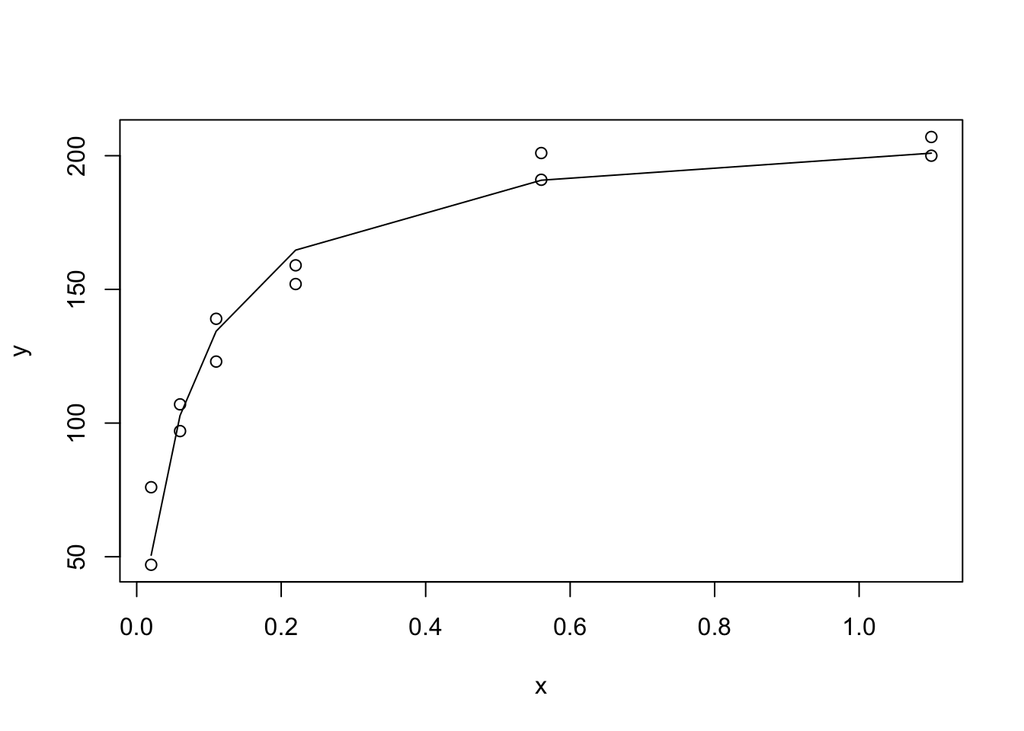

```r
plot(y ~ x, data = Puromycin)
lines(Puromycin$x, fitted.values(lmfit))
```

- Observe that the overall fit is satisfactory.

# Ch.13 Generalized Linear Models (GLMs)

- We consider the ‘Penumoconiosis Data’ (Example 13.1, p.445). This data concerns the proportion of coal miners who exhibit symptoms of severe pneumoconiosis ($y$) and the number of years of exposure ($x$).
- The `glm()` function can be used to fit many types of generalized linear models, such as logistic regression, poisson regression, etc. The syntax of the `glm()` function is similar to that of `lm()`, except that we must pass in the argument `family = binomial` in order to tell R to run a logistic regression rather than some other type of generalized linear model.
- A response is given as a two-column integer matrix: the first column gives the number of successes and the second the number of failures.

```r
pneumoconiosis <- read.csv("pneumoconiosis.csv")
colnames(pneumoconiosis) <- c("x","pneum","miners","y")
glmfit <- glm(cbind(pneum, miners-pneum) ~ x, family = binomial, data = pneumoconiosis)
summary(glmfit)
```

```
##
## Call:
## glm(formula = cbind(pneum, miners - pneum) ~ x, family = binomial,
##     data = pneumoconiosis)
##
## Coefficients:
##             Estimate Std. Error z value Pr(>|z|)
## (Intercept) -4.79648    0.56859  -8.436  < 2e-16 ***
## x            0.09346    0.01543   6.059 1.37e-09 ***
## ---
## Signif. codes:  0 '***' 0.001 '**' 0.01 '*' 0.05 '.' 0.1 ' ' 1
##
## (Dispersion parameter for binomial family taken to be 1)
##
##     Null deviance: 56.9028  on 7  degrees of freedom
## Residual deviance:  6.0508  on 6  degrees of freedom
## AIC: 32.877
##
## Number of Fisher Scoring iterations: 4
```

- Why can’t we just write `y ~ x`? Recall that in the logistic regression model, $y_i$ takes on the **value either 0 or 1**. It is $E(y_i)$ that is **between** 0 and 1. In the dataset above, `y` takes a value between 0 and 1. This means that `pneumoconiosis$y` is not in an appropriate form for the logisitic regression model. In fact, it is in a **summarized** form.
- For example, `y[8] == 5/11` means that the *raw* data is actually 11 observations with 5 ones (success) and 6 zeros (failure). This is exactly what the code above supplies to the `glm()` function: the number of successes and failures. However, if you just write `y ~ x`, information on the total number of cases (`miners`) is lost.
- So if you convert the dataset to its raw form, you do not have to specify the response in a matrix form.

```r
success <- sum(pneumoconiosis$pneum)
failure <- sum(pneumoconiosis$miners) - success
y.new <- rep(c(1,0),c(success, failure))
x.new <- c(rep(pneumoconiosis$x, pneumoconiosis$pneum),
           rep(pneumoconiosis$x, pneumoconiosis$miners - pneumoconiosis$pneum))
glm(y.new ~ x.new, family = binomial, data = pneumoconiosis)
```

```
##
## Call:  glm(formula = y.new ~ x.new, family = binomial, data = pneumoconiosis)
##
## Coefficients:
## (Intercept)        x.new
##    -4.79648      0.09346
##
## Degrees of Freedom: 370 Total (i.e. Null);  369 Residual
## Null Deviance:       270.2
## Residual Deviance: 219.3     AIC: 223.3
```

- Otherwise, you can give the total number cases using the argument `weights`.

```r
glm(y ~ x, family = binomial, weights = miners, data = pneumoconiosis)
```

```
##
## Call:  glm(formula = y ~ x, family = binomial, data = pneumoconiosis,
##     weights = miners)
##
## Coefficients:
## (Intercept)            x
##    -4.79613      0.09345
##
## Degrees of Freedom: 7 Total (i.e. Null);  6 Residual
## Null Deviance:       56.9
## Residual Deviance: 6.056     AIC: 32.88
```

- You can use `summary()`, `coef()` (`coefficients()`), `fitted.values()`, and `residuals()` functions as if using the `lm()` function.

```r
coef(glmfit)
fitted.values(glmfit)
residuals(glmfit)
```

- The `predict()` function can be used to make predictions. When the argument `type = "response"` $\exp(\boldsymbol{x}^\top\hat{\boldsymbol{\beta}})/[1+\exp(\boldsymbol{x}^\top\hat{\boldsymbol{\beta}})]$ is returned. If this argument is omitted, the default option is used (`type = "link"`), and the function returns $\boldsymbol{x}^\top\hat{\boldsymbol{\beta}}$. To make predictions at new $\boldsymbol{x}$, use the `newdata` argument. If no `newdata` is supplied, then the `predict()` function returns the predictions for the data that was used to fit the logistic regression model.

```r
predict(glmfit)
```

```
##           1           2           3           4           5           6
## -4.25439538 -3.39453659 -2.78702766 -2.22625018 -1.66547271 -1.10469523
##           7           8
## -0.49718630  0.01685971
```

```r
model.matrix(glmfit) %*% coef(glmfit)
```

```
##          [,1]
## 1 -4.25439538
## 2 -3.39453659
## 3 -2.78702766
## 4 -2.22625018
## 5 -1.66547271
## 6 -1.10469523
## 7 -0.49718630
## 8  0.01685971
```

```r
predict(glmfit, type = "response")
```

```
##          1          2          3          4          5          6          7
## 0.01400281 0.03246665 0.05802922 0.09741786 0.15902872 0.24886118 0.37820213
##          8
## 0.50421483
```

- To fit a poisson regression model, set `family = poisson`, instead of `family = binomial`. We do not cover this model in this lab session. D.I.Y. and have a great summer vacation!

### References

- *Introduction to Linear Regression Analysis*, 6th Edition, by Montgomery, Peck & Vining, Wiley (2021).
- *An Introduction to Statistical Learning*, 2nd Edition, by James, Witten, Hastie & Tibshirani, Springer (2021).